# Lab2

Yangzom Dolma

# Tasks

## Task 1

```r
getwd()
```

```
## [1] "C:/Users/Admin/Desktop/Fall 2020/Math 4753/Labs/LAB2"
```

## Task 2

```r
epagas = read.csv("EPAGAS.csv")
head(epagas, 6)
```

```
##   ï..MPG
## 1   36.3
## 2   41.0
## 3   36.9
## 4   37.1
## 5   44.9
## 6   36.8
```

## Task 3

Make the object mpg, the number of miles per gallon vector

```r
mpg = epagas$ï..MPG
head(mpg)
```

```
## [1] 36.3 41.0 36.9 37.1 44.9 36.8
```

Transform the mpg variable to z and verify these results.

```r
z= (mpg - mean(mpg))/sd(mpg)
head(z)
```

```
## [1] -0.28702628  1.65681163 -0.03887676  0.04383975  3.26978352 -0.08023501
```

```r
print(paste0("mean = ", round(mean(mpg), digits = 4)), quote = FALSE)
```

```
## [1] mean = 36.994
```

```r
print(paste0("variance = ", var(z)), quote = FALSE)
```

```
## [1] variance = 1
```

```r
print(paste0("standard deviation = ", sd(z)), quote = FALSE)
```

```
## [1] standard deviation = 1
```

Using z, the values of mpg that are possible outliers are:

```r
mpg[abs(z)>= 2 & abs(z) <= 3]
```

```
## [1] 30.0 42.1 31.8
```

Using z, the values of mpg that is defined as outliers:

```r
mpg[abs(z) > 3]
```

```
## [1] 44.9
```

Dotplot using lattice package.

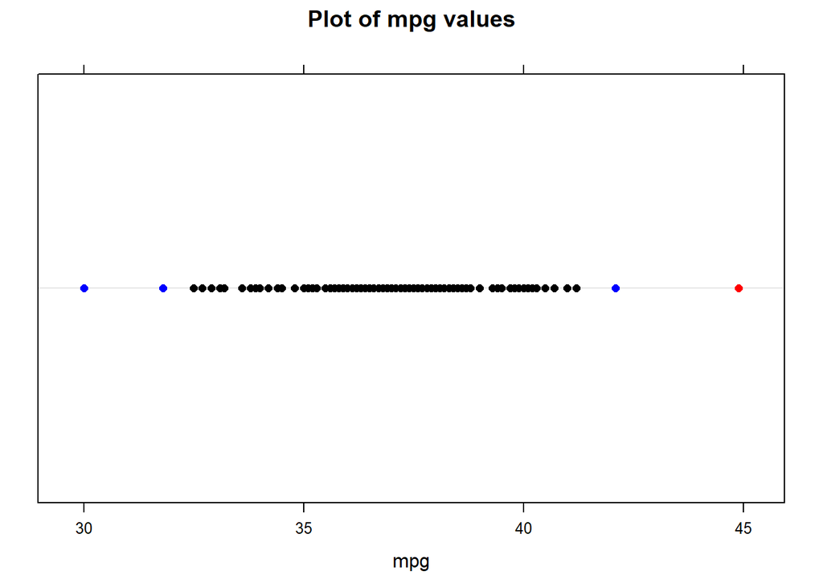

```r
mycol = ifelse(abs(z)>3, "Red",
               ifelse(abs(z)>=2 &abs(z)<=3,"Blue", "Black"))
mypch = ifelse(abs(z)>3, 20,
               ifelse(abs(z)>=2 &abs(z)<=3,21, 22))
library(lattice)
dotplot(mpg,col=mycol, main = "Plot of mpg values")
```

## Task 4

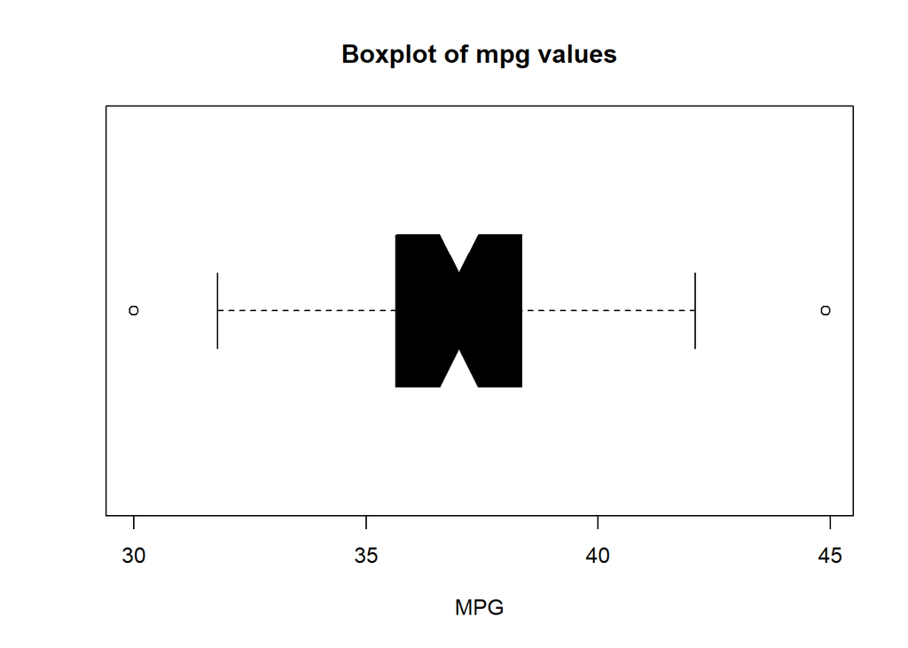

```r
boxplot(mpg, main = "Boxplot of mpg values", xlab = "MPG", col = "black", horizontal = TRUE, notch = TRUE)
```

Using Chebyshev’s Theorem, at least 1 - 1/k^2 of the data lie within k standard deviations of the mean.

When k = 2,

```r
k = 2
chebval  = 1-1/(k^2)
chebval
```

```
## [1] 0.75
```

The exact proportion of data within 2 standard deviation of the mean:

```r
exactProportion = length(mpg[abs(z) < 2])/length(mpg)
exactProportion
```

```
## [1] 0.96
```

In Chebyshev’s Theorem, at least 8/9 of the data lie within 3 standard deviation of the mean.

```r
k = 3
chebval = 1- 1/(k^2)
chebval
```

```
## [1] 0.8888889
```

The exact proportion of data within 3 standard deviations of the mean:

```r
exactProportion = length(mpg[abs(z)<3])/length(mpg)
exactProportion
```

```
## [1] 0.99
```

Does Chebyshev agree with the data?

```r
compare = length(mpg[mean(mpg)-2*sd(mpg) < mpg & mpg < mean(mpg)+ 2*sd(mpg) ])/length(mpg)
compare
```

```
## [1] 0.96
```

The Chebyshev correspond well with the Empirical rule when the standard deviation is 2. The prediction of the amount of data within 2 standard deviation of the mean is around 96%.

Therefore the Empirical Rule is quite valid in this case because the data is approximately bell-shaped.